# Wildlife Detection Capstone: Results Notebook

### 1.2 Antelope: a second, subtler shift

One video, cut in time: early frames are a close-up of one animal; later frames are a distant herd.

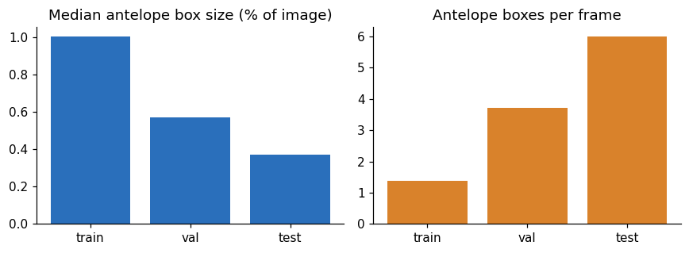

```python
a = sh[(sh.dataset=="wildlife-yolo") & (sh["class"]=="antelope")].set_index("split").loc[order]
a = a.assign(per_frame=a.boxes/a.frames)
fig, ax = plt.subplots(1,2, figsize=(8,3))
ax[0].bar(order, a.median_area_pct, color="#2a6fbb"); ax[0].set_title("Median antelope box size (% of image)")
ax[1].bar(order, a.per_frame, color="#d9822b"); ax[1].set_title("Antelope boxes per frame")
fig.tight_layout(); fig.savefig(F/"03_antelope_shift.png"); plt.show()
```

### 1.1b Matched check: is the chimpanzee jump caused by the split? (old split, same S0 settings)

Three seeds trained on the OLD split with augmentation off (exactly the S0 settings), then scored on both the old and the fixed evaluation sets.

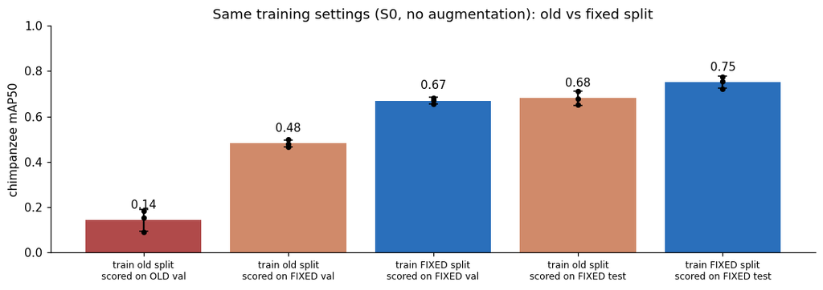

```python
n_own = pd.read_csv(D/"n0_on_naive_val.csv"); n_fv = pd.read_csv(D/"n0_on_fixed_val.csv"); n_ft = pd.read_csv(D/"n0_on_fixed_test.csv")
s0v = res[res.config=="S0"]; s0t = pd.read_csv(D/"test_default.csv"); s0t = s0t[s0t.run.str.startswith("S0_baseline")]
c = "chimpanzee"
bars = [("train old split\nscored on OLD val", n_own[n_own["class"]==c].mAP50, "#b04a4a"),
        ("train old split\nscored on FIXED val", n_fv[n_fv["class"]==c].mAP50, "#d08a6a"),
        ("train FIXED split\nscored on FIXED val", s0v[s0v["class"]==c].mAP50, "#2a6fbb"),
        ("train old split\nscored on FIXED test", n_ft[n_ft["class"]==c].mAP50, "#d08a6a"),
        ("train FIXED split\nscored on FIXED test", s0t[s0t["class"]==c].mAP50, "#2a6fbb")]
fig, ax = plt.subplots(figsize=(10,3.6))
for i,(lab,v,col) in enumerate(bars):
    ax.bar(i, v.mean(), yerr=v.std(ddof=1), color=col, capsize=4); ax.scatter([i]*len(v), v, color="k", s=14, zorder=3)
    ax.text(i, v.mean()+0.05, f"{v.mean():.2f}", ha="center")
ax.set_xticks(range(len(bars))); ax.set_xticklabels([b[0] for b in bars], fontsize=8); ax.set_ylabel("chimpanzee mAP50"); ax.set_ylim(0,1)
ax.set_title("Same training settings (S0, no augmentation): old vs fixed split")
fig.tight_layout(); fig.savefig(F/"02b_chimp_matched_check.png"); plt.show()
```

## 2. Ablation results (validation set, 3 seeds)

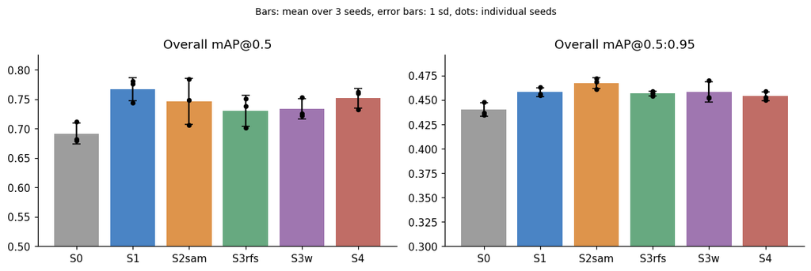

```python
fig, axs = plt.subplots(1,2, figsize=(11,3.6))
for ax, metric, title in zip(axs, ["mAP50","mAP50-95"], ["mAP@0.5","mAP@0.5:0.95"]):
    a = res[res["class"]=="all"]
    for i,c in enumerate(CFG):
        v = a[a.config==c][metric].values
        ax.bar(i, v.mean(), yerr=v.std(ddof=1), color=COL[c], capsize=4, alpha=.85)
        ax.scatter([i]*len(v), v, color="k", s=14, zorder=3)
    ax.set_xticks(range(len(CFG))); ax.set_xticklabels(CFG); ax.set_title(f"Overall {title}"); ax.set_ylim(0.3 if metric=="mAP50-95" else 0.5, None)
fig.suptitle("Bars: mean over 3 seeds, error bars: 1 sd, dots: individual seeds", y=1.0, fontsize=9)
fig.tight_layout(); fig.savefig(F/"04_overall_ablation.png"); plt.show()
```

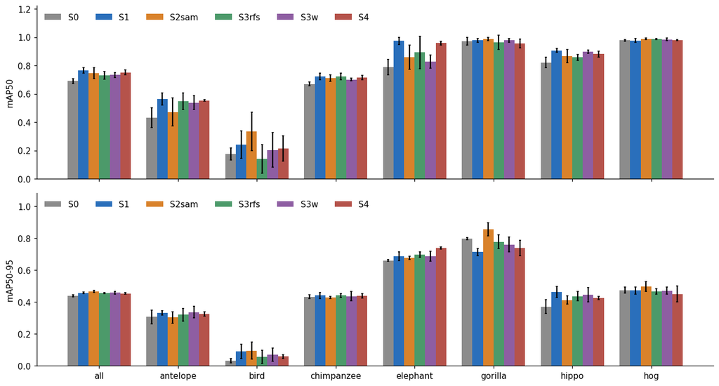

```python
fig, axs = plt.subplots(2,1, figsize=(12,6.5), sharex=True)
cl = ["all"]+CLASSES
for ax, metric in zip(axs, ["mAP50","mAP50-95"]):
    w=0.8/len(CFG)
    for i,c in enumerate(CFG):
        m = [res[(res.config==c)&(res["class"]==k)][metric].mean() for k in cl]
        s = [res[(res.config==c)&(res["class"]==k)][metric].std(ddof=1) for k in cl]
        ax.bar(np.arange(len(cl))+(i-(len(CFG)-1)/2)*w, m, w, yerr=s, capsize=1.5, label=c, color=COL[c])
    ax.set_ylabel(metric); ax.set_ylim(0, ax.get_ylim()[1]*1.15); ax.legend(frameon=False, ncol=6, loc="upper left")
axs[1].set_xticks(range(len(cl))); axs[1].set_xticklabels(cl)
fig.tight_layout(); fig.savefig(F/"05_per_class_ablation.png"); plt.show()
```

```python
rows=[]
for k in ["all"]+CLASSES:
    r={"class":k}
    for metric in ["mAP50","mAP50-95","recall"]:
        for c in CFG:
            v=res[(res.config==c)&(res["class"]==k)][metric]
            r[f"{metric} {c}"]=f"{v.mean():.3f} ± {v.std(ddof=1):.3f}"
    rows.append(r)
tab=pd.DataFrame(rows).set_index("class"); tab.to_csv(F/"table_mean_sd.csv", encoding="utf-8-sig"); tab
```

| class | mAP50 S0 | mAP50 S1 | mAP50 S2sam | mAP50 S3rfs | mAP50 S3w | mAP50 S4 | mAP50-95 S0 | mAP50-95 S1 | mAP50-95 S2sam | mAP50-95 S3rfs | mAP50-95 S3w | mAP50-95 S4 | recall S0 | recall S1 | recall S2sam | recall S3rfs | recall S3w | recall S4 |
| --- | --- | --- | --- | --- | --- | --- | --- | --- | --- | --- | --- | --- | --- | --- | --- | --- | --- | --- |
| all | 0.691 ± 0.018 | 0.767 ± 0.020 | 0.746 ± 0.039 | 0.730 ± 0.026 | 0.733 ± 0.017 | 0.751 ± 0.017 | 0.440 ± 0.007 | 0.458 ± 0.004 | 0.467 ± 0.006 | 0.457 ± 0.003 | 0.458 ± 0.010 | 0.454 ± 0.005 | 0.658 ± 0.025 | 0.702 ± 0.035 | 0.720 ± 0.034 | 0.702 ± 0.017 | 0.702 ± 0.034 | 0.713 ± 0.013 |
| antelope | 0.433 ± 0.069 | 0.565 ± 0.043 | 0.472 ± 0.100 | 0.548 ± 0.057 | 0.538 ± 0.050 | 0.553 ± 0.005 | 0.307 ± 0.043 | 0.333 ± 0.014 | 0.303 ± 0.037 | 0.321 ± 0.039 | 0.336 ± 0.036 | 0.325 ± 0.014 | 0.432 ± 0.020 | 0.460 ± 0.020 | 0.457 ± 0.054 | 0.503 ± 0.053 | 0.469 ± 0.093 | 0.476 ± 0.021 |
| bird | 0.175 ± 0.043 | 0.242 ± 0.098 | 0.335 ± 0.136 | 0.141 ± 0.100 | 0.204 ± 0.121 | 0.215 ± 0.089 | 0.031 ± 0.014 | 0.092 ± 0.045 | 0.096 ± 0.053 | 0.056 ± 0.041 | 0.070 ± 0.042 | 0.058 ± 0.011 | 0.047 ± 0.023 | 0.049 ± 0.052 | 0.289 ± 0.075 | 0.051 ± 0.044 | 0.114 ± 0.106 | 0.127 ± 0.092 |
| chimpanzee | 0.670 ± 0.014 | 0.723 ± 0.022 | 0.712 ± 0.023 | 0.723 ± 0.025 | 0.701 ± 0.009 | 0.716 ± 0.016 | 0.434 ± 0.010 | 0.442 ± 0.020 | 0.429 ± 0.006 | 0.441 ± 0.013 | 0.437 ± 0.029 | 0.440 ± 0.014 | 0.613 ± 0.015 | 0.630 ± 0.063 | 0.680 ± 0.023 | 0.680 ± 0.044 | 0.684 ± 0.036 | 0.680 ± 0.010 |
| elephant | 0.788 ± 0.055 | 0.974 ± 0.025 | 0.859 ± 0.086 | 0.892 ± 0.116 | 0.828 ± 0.048 | 0.958 ± 0.015 | 0.661 ± 0.005 | 0.688 ± 0.028 | 0.676 ± 0.010 | 0.697 ± 0.016 | 0.687 ± 0.031 | 0.739 ± 0.006 | 0.787 ± 0.058 | 0.981 ± 0.032 | 0.833 ± 0.111 | 0.871 ± 0.115 | 0.796 ± 0.032 | 0.899 ± 0.041 |
| gorilla | 0.973 ± 0.027 | 0.978 ± 0.014 | 0.988 ± 0.011 | 0.963 ± 0.049 | 0.978 ± 0.014 | 0.956 ± 0.030 | 0.798 ± 0.005 | 0.714 ± 0.023 | 0.857 ± 0.042 | 0.779 ± 0.042 | 0.761 ± 0.047 | 0.741 ± 0.049 | 0.947 ± 0.070 | 0.961 ± 0.040 | 0.989 ± 0.013 | 0.963 ± 0.040 | 0.966 ± 0.011 | 0.947 ± 0.027 |
| hippo | 0.822 ± 0.036 | 0.907 ± 0.013 | 0.866 ± 0.046 | 0.857 ± 0.023 | 0.898 ± 0.010 | 0.881 ± 0.022 | 0.372 ± 0.042 | 0.464 ± 0.034 | 0.413 ± 0.026 | 0.436 ± 0.029 | 0.446 ± 0.044 | 0.426 ± 0.010 | 0.811 ± 0.102 | 0.867 ± 0.066 | 0.814 ± 0.123 | 0.874 ± 0.040 | 0.913 ± 0.022 | 0.896 ± 0.036 |
| hog | 0.978 ± 0.007 | 0.977 ± 0.012 | 0.989 ± 0.006 | 0.988 ± 0.004 | 0.985 ± 0.011 | 0.980 ± 0.004 | 0.475 ± 0.018 | 0.473 ± 0.023 | 0.497 ± 0.031 | 0.466 ± 0.017 | 0.472 ± 0.022 | 0.451 ± 0.051 | 0.963 ± 0.012 | 0.962 ± 0.019 | 0.976 ± 0.031 | 0.973 ± 0.017 | 0.971 ± 0.008 | 0.964 ± 0.013 |

```python
# Which differences are bigger than seed noise?  Welch t-statistic over 3 seeds; |t|>2.8 is roughly p<0.05 at ~4 d.o.f.
from math import sqrt
def welch(a,b):
    return (b.mean()-a.mean())/sqrt(a.var(ddof=1)/len(a)+b.var(ddof=1)/len(b))
out=[]
for pair in [("S0","S1")]+[("S1",c) for c in CFG[2:]]:
    for k in ["all"]+CLASSES:
        for metric in ["mAP50","mAP50-95","recall"]:
            a=res[(res.config==pair[0])&(res["class"]==k)][metric]; b=res[(res.config==pair[1])&(res["class"]==k)][metric]
            t=welch(a,b); out.append([f"{pair[0]} -> {pair[1]}",k,metric,b.mean()-a.mean(),t,abs(t)>2.8])
sig=pd.DataFrame(out,columns=["comparison","class","metric","change","t","beyond_noise"])
sig.to_csv(F/"table_significance.csv",index=False)
print("Differences beyond seed noise (|t| > 2.8, 3 seeds; indicative only, not a formal test):")
sig[sig.beyond_noise].round(3).sort_values(["comparison","metric"])
```

```
Differences beyond seed noise (|t| > 2.8, 3 seeds; indicative only, not a formal test):
```

|  | comparison | class | metric | change | t | beyond_noise |
| --- | --- | --- | --- | --- | --- | --- |
| 0 | S0 -> S1 | all | mAP50 | 0.075 | 4.895 | True |
| 3 | S0 -> S1 | antelope | mAP50 | 0.132 | 2.811 | True |
| 9 | S0 -> S1 | chimpanzee | mAP50 | 0.053 | 3.505 | True |
| 12 | S0 -> S1 | elephant | mAP50 | 0.186 | 5.309 | True |
| 18 | S0 -> S1 | hippo | mAP50 | 0.086 | 3.874 | True |
| 1 | S0 -> S1 | all | mAP50-95 | 0.018 | 3.781 | True |
| 16 | S0 -> S1 | gorilla | mAP50-95 | -0.084 | -6.143 | True |
| 19 | S0 -> S1 | hippo | mAP50-95 | 0.092 | 2.951 | True |
| 14 | S0 -> S1 | elephant | recall | 0.194 | 5.057 | True |
| 40 | S1 -> S2sam | gorilla | mAP50-95 | 0.144 | 5.200 | True |
| 32 | S1 -> S2sam | bird | recall | 0.240 | 4.551 | True |
| 66 | S1 -> S3rfs | hippo | mAP50 | -0.050 | -3.355 | True |
| 84 | S1 -> S3w | elephant | mAP50 | -0.146 | -4.708 | True |
| 86 | S1 -> S3w | elephant | recall | -0.185 | -7.071 | True |
| 109 | S1 -> S4 | elephant | mAP50-95 | 0.051 | 3.040 | True |

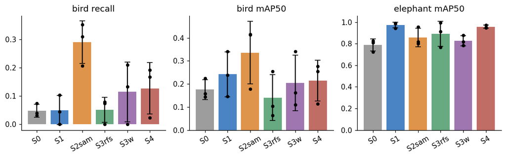

```python
fig, axs = plt.subplots(1,3, figsize=(10,3.2))
for ax,(k,metric) in zip(axs,[("bird","recall"),("bird","mAP50"),("elephant","mAP50")]):
    for i,c in enumerate(CFG):
        v=res[(res.config==c)&(res["class"]==k)][metric].values
        ax.bar(i, v.mean(), yerr=v.std(ddof=1), color=COL[c], capsize=4, alpha=.85); ax.scatter([i]*len(v), v, color="k", s=14, zorder=3)
    ax.set_xticks(range(len(CFG))); ax.set_xticklabels(CFG, rotation=30); ax.set_title(f"{k} {metric}")
fig.tight_layout(); fig.savefig(F/"06_bird_elephant.png"); plt.show()
```

## 4. Training curves

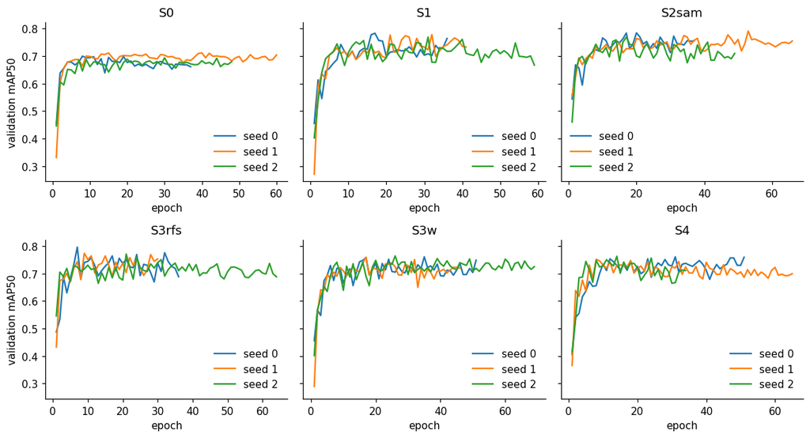

```python
fig, axs = plt.subplots(2,3, figsize=(11,6), sharey=True)
names={"S0":"S0_baseline_seed{}","S1":"S1_augment_seed{}","S2sam":"S2sam_seed{}","S3rfs":"S3rfs_seed{}","S3w":"S3w_seed{}","S4":"S4ps_seed{}"}
for ax,c in zip(axs.ravel(),CFG):
    for s in range(3):
        d=pd.read_csv(D/"runs"/(names[c].format(s)+".csv")); d.columns=[x.strip() for x in d.columns]
        ax.plot(d["epoch"], d["metrics/mAP50(B)"], label=f"seed {s}")
    ax.set_title(c); ax.set_xlabel("epoch"); ax.legend(frameon=False)
axs[0,0].set_ylabel("validation mAP50"); axs[1,0].set_ylabel("validation mAP50")
fig.tight_layout(); fig.savefig(F/"07_training_curves.png"); plt.show()
```

## 5. Confusion matrices

**Read the threshold first.** Ultralytics draws confusion matrices at the validation confidence threshold, which defaults to 0.001. At that setting thousands of near-zero-confidence boxes are counted, so the matrices show species mix-ups and false alarms that do not happen at a working threshold. The first figure (validation set, saved during training) is at 0.001 and is kept only for completeness. The second figure (test set) is drawn at confidence 0.25 and is the one to read.

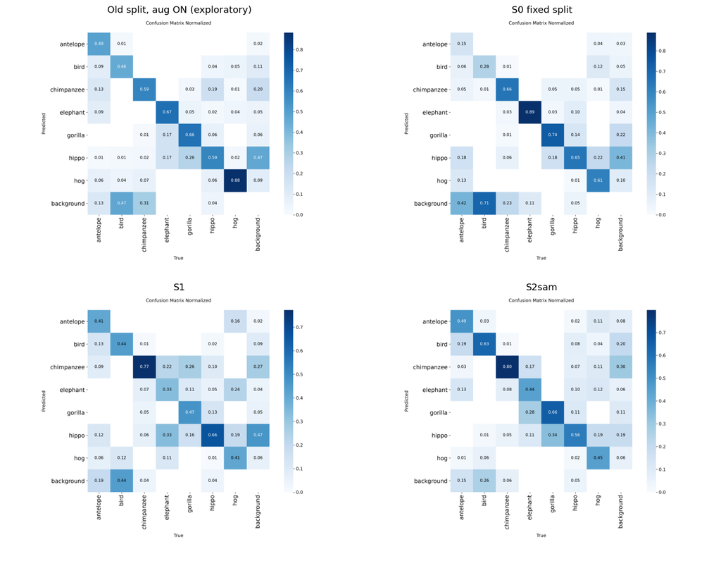

```python
ims=[("naive_exploratory","Old split, aug ON (exploratory)"),("S0_baseline_seed0","S0 fixed split"),("S1_augment_seed0","S1"),("S2sam_seed0","S2sam")]
fig, axs = plt.subplots(2,2, figsize=(13,10))
for ax,(f,t) in zip(axs.ravel(),ims): ax.imshow(mpimg.imread(D/"confusion"/f"{f}.png")); ax.set_title(t); ax.axis("off")
fig.tight_layout(); fig.savefig(F/"08_confusion_matrices.png"); plt.show()
```

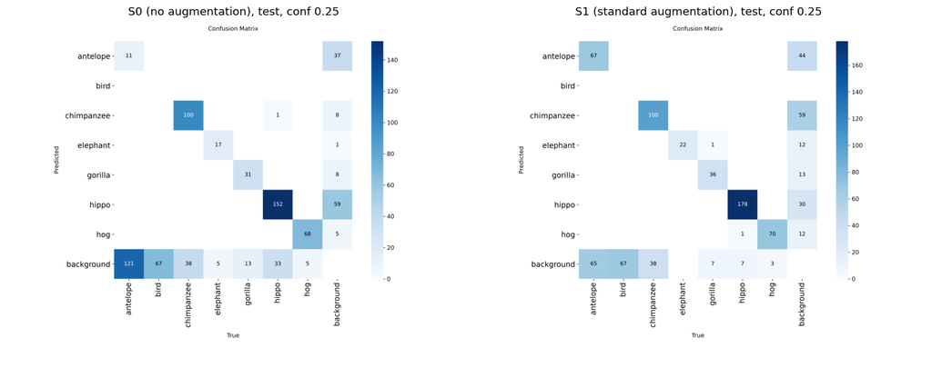

|  | class | gt_boxes | found_correct | found_wrong_class | missed | false_positive_boxes |
| --- | --- | --- | --- | --- | --- | --- |
| 0 | antelope | 132 | 60 | 0 | 72 | 48 |
| 1 | bird | 67 | 0 | 0 | 67 | 0 |
| 2 | chimpanzee | 138 | 98 | 0 | 40 | 59 |
| 3 | elephant | 22 | 22 | 0 | 0 | 11 |
| 4 | gorilla | 44 | 32 | 0 | 12 | 15 |
| 5 | hippo | 186 | 181 | 0 | 5 | 41 |
| 6 | hog | 73 | 67 | 0 | 6 | 12 |

```python
T = D/"test_plots"
fig, axs = plt.subplots(1,2, figsize=(14,5.6))
for ax,(f,ttl) in zip(axs,[("S0s0_conf0.25_confusion_matrix.png","S0 (no augmentation), test, conf 0.25"),("S1s0_conf0.25_confusion_matrix.png","S1 (standard augmentation), test, conf 0.25")]):
    ax.imshow(mpimg.imread(T/f)); ax.set_title(ttl); ax.axis("off")
fig.tight_layout(); fig.savefig(F/"08b_confusion_test_conf025.png"); plt.show()
ec = pd.read_csv(D/"error_counts.csv"); ec
```

## 6. The copy-paste training set (S2sam)

```python
mf=pd.read_csv(D/"cp_manifest.csv")
print(len(mf["synthetic"].unique()), "synthetic images,", len(mf), "pasted animals")
pc=mf.pasted_class.value_counts(); uc=mf.groupby("pasted_class").cutout.nunique()
pd.DataFrame({"pasted":pc,"distinct_cutouts_used":uc})
```

```
400 synthetic images, 777 pasted animals
```

| pasted_class | pasted | distinct_cutouts_used |
| --- | --- | --- |
| antelope | 243 | 90 |
| bird | 238 | 95 |
| elephant | 296 | 36 |

## 6b. Test-set results (default split, first and only use of the test set)

Configuration choice (S1) was made on validation; these scores are not used for selection.

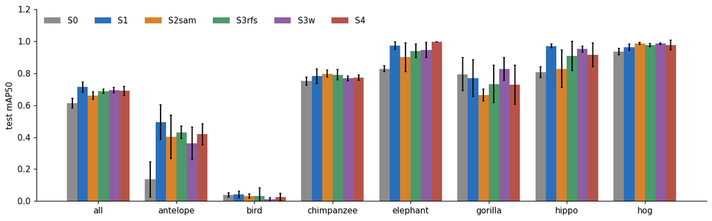

| cfg class | S0 | S1 | S2sam | S3rfs | S3w | S4 |
| --- | --- | --- | --- | --- | --- | --- |
| all | 0.612 | 0.713 | 0.658 | 0.687 | 0.693 | 0.690 |
| antelope | 0.136 | 0.492 | 0.402 | 0.431 | 0.362 | 0.418 |
| bird | 0.039 | 0.041 | 0.032 | 0.033 | 0.010 | 0.026 |
| chimpanzee | 0.750 | 0.781 | 0.797 | 0.790 | 0.767 | 0.772 |
| elephant | 0.826 | 0.973 | 0.900 | 0.939 | 0.946 | 0.995 |
| gorilla | 0.793 | 0.768 | 0.664 | 0.733 | 0.827 | 0.728 |
| hippo | 0.805 | 0.970 | 0.827 | 0.908 | 0.951 | 0.915 |
| hog | 0.935 | 0.962 | 0.986 | 0.977 | 0.986 | 0.975 |

```python
td = pd.read_csv(D/"test_default.csv"); td["cfg"] = td.run.str.replace(r"_seed\d","",regex=True)
ren = {"S0_baseline":"S0","S1_augment":"S1","S2sam":"S2sam","S3rfs":"S3rfs","S3w":"S3w","S4ps":"S4"}; td["cfg"] = td.cfg.map(ren)
fig, ax = plt.subplots(figsize=(12,3.8)); cl = ["all"]+CLASSES; w = 0.8/len(CFG)
for i,c in enumerate(CFG):
    m = [td[(td.cfg==c)&(td["class"]==k)]["mAP50"].mean() for k in cl]
    s = [td[(td.cfg==c)&(td["class"]==k)]["mAP50"].std(ddof=1) for k in cl]
    ax.bar(np.arange(len(cl))+(i-(len(CFG)-1)/2)*w, m, w, yerr=s, capsize=1.5, label=c, color=COL[c])
ax.set_xticks(range(len(cl))); ax.set_xticklabels(cl); ax.set_ylabel("test mAP50"); ax.legend(frameon=False, ncol=6, loc="upper left"); ax.set_ylim(0,1.2)
fig.tight_layout(); fig.savefig(F/"09_test_per_class.png"); plt.show()
t = td.pivot_table(index="class", columns="cfg", values="mAP50", aggfunc="mean").round(3)[CFG]; t.to_csv(F/"table_test_mAP50.csv"); t
```

## 6c. Experiment A: holding out whole recording sessions

Models trained on gorillas, gorillas2 and hippo2 only; tested on the unseen sessions gorillas3 and hippo. The default-split column uses different test images and far more training data, so the comparison shows the size of the problem, not a precise gap.

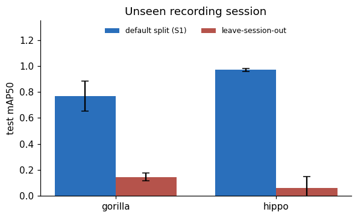

|  | class | default_mean | default_sd | lso_mean | lso_sd |
| --- | --- | --- | --- | --- | --- |
| 0 | gorilla | 0.768 | 0.117 | 0.147 | 0.031 |
| 1 | hippo | 0.970 | 0.011 | 0.064 | 0.087 |

```python
ld = pd.read_csv(D/"test_lso.csv")
rows = []
for k in ["gorilla","hippo"]:
    a = td[(td.cfg=="S1")&(td["class"]==k)]["mAP50"]; b = ld[ld["class"]==k]["mAP50"]
    rows.append([k, a.mean(), a.std(ddof=1), b.mean(), b.std(ddof=1)])
ea = pd.DataFrame(rows, columns=["class","default_mean","default_sd","lso_mean","lso_sd"])
fig, ax = plt.subplots(figsize=(5.5,3.4)); x = np.arange(2)
ax.bar(x-0.19, ea.default_mean, 0.38, yerr=ea.default_sd, capsize=4, label="default split (S1)", color=COL["S1"])
ax.bar(x+0.19, ea.lso_mean, 0.38, yerr=ea.lso_sd, capsize=4, label="leave-session-out", color="#b5534b")
ax.set_xticks(x); ax.set_xticklabels(ea["class"]); ax.set_ylabel("test mAP50"); ax.set_ylim(0, 1.35); ax.legend(frameon=False, loc="upper center", ncol=2, fontsize=8); ax.set_title("Unseen recording session")
fig.tight_layout(); fig.savefig(F/"10_experiment_A.png"); plt.show(); ea.round(3)
```